# Modeling TCRS: Preliminary results for discussion

# 1 **Overview of key risk-sharing features**

Key policy features:

1. **DB-DC hybrid plan**. New hires after July 1, 2014 participate in a DB-DC hybrid plan.
   - DB component: ERC rate = 4%, EEC rate = 5%; 1% benefit factor
   - DC component: ERC rate = 5%, EEC rate = 2%
2. **Cost control provisions**.
   - The ADC rate shall not exceed 4% of payroll; the UAAL shall not exceed 12.5% of the five year average of the state’s long-term indebtedness.
   - The state has established a stabilization reserve account and plans to contribute to the stabilization reserve account when the actuarially determined contribution rate is less than 4% of payroll.
   - If the control provisions are exceeded, the adjustments will automatically occur in the following sequence:
     1. Utilize funds in the stabilization reserve, if any
     2. Reduce or suspend the 3% retiree COLA benefit
     3. Shift some or all of the employer contributions from the defined contribution plan to the hybrid defined benefit plan
     4. Increase employee contributions by 1% of salary
     5. Reduce future service accrual below 1%
     6. Freeze the plan, no future service accrual
   - When the employer cost is restored to 4% and the unfunded liabilities do not exceed the maximum level, then the adjustments previously made are restored on a prospective basis. The sequence is in reverse order.

# 2 **Summary of modeling approach**

## 2.1 Policy scenarios

To examine the impact of the TCRS risk-sharing features on plan costs, funded status, and member benefit, we run the simulation under the following three policy scenarios.

1. **TCRS policy: hybrid plan with cost control provisions**
   - Currently the the model incorporates the stabilization reserve and cost control adjusments 1-4.
   - The cost control provision for limit of UAAL is not incorporated in the model.
2. **Hybrid plan with no TCRS cost control features**
   - The same as 1 except for the TCRS stabilization reserve and cost control provisions.
3. **A pure DB plan similar to the DB component of TCRS hybrid plan, but with 2% benefit factor**
   - This DB plan is about twice as large as the DB component of the TCRS hybrid plan.

Additional variants will be examined in future analysis.

## 2.2 Investment return scenarios

1. Stochastic: 7.25% expected mean return, 12% standard deviation. This is just for purposes of initial analysis. Will be replaced by scenarios and capital market assumptions provided by Pew.

## 2.3 Model assumptions and Simplifications

- Currently only the sub-plan for teachers is modeled. Will model the sub-plan for other employees in later versions.
- Benefit rules for the sub-plan for teachers:
  - Normal retirement requirement: age >= 60 or age + years of service >= 90
  - Benefit factor: 1% per year of service
- Key valuation methods and assumptions:
  - Discount rate: 7.25%
  - Cost method: EAN
  - Asset smoothing: 10 years with a +-20% corridor
  - Amortization of UAAL: 20-year level-dollar closed amortization

# 3 **Simulation results**

## 3.1 Analysis of contributions

### 3.1.1 Distribution of long-term costs

(Click tabs below to show tables)

#### PV of total contribution with terminal UAAL

Distribution of 30-year present value of total contribution plus terminal UAAL

| Policy | 90th | 75th | 50th | 25th | 10th |
| --- | --- | --- | --- | --- | --- |
| Hybrid; 1% DB factor; Cost control | 100.0 | 100.0 | 100.0 | 100.0 | 100.0 |
| Hybrid; 1% DB factor; No cost control | 92.8 | 89.0 | 85.0 | 81.4 | 79.3 |
| DB; 2% DB factor; No cost control | 95.3 | 87.6 | 79.0 | 69.1 | 61.3 |

#### PV of employer contribution

Distribution of 30-year present value of ERC

| Policy | 90th | 75th | 50th | 25th | 10th |
| --- | --- | --- | --- | --- | --- |
| Hybrid; 1% DB factor; Cost control | 100.0 | 100.0 | 100.0 | 100.0 | 100.0 |
| Hybrid; 1% DB factor; No cost control | 87.3 | 80.5 | 73.3 | 66.9 | 63.2 |
| DB; 2% DB factor; No cost control | 113.9 | 100.2 | 84.8 | 67.3 | 53.3 |

#### PV of employee contribution

Distribution of 30-year present value of EEC

| Policy | 90th | 75th | 50th | 25th | 10th |
| --- | --- | --- | --- | --- | --- |
| Hybrid; 1% DB factor; Cost control | 100.0 | 100.0 | 100.0 | 100.0 | 100.0 |
| Hybrid; 1% DB factor; No cost control | 100.0 | 100.0 | 100.0 | 100.0 | 100.0 |
| DB; 2% DB factor; No cost control | 71.4 | 71.4 | 71.4 | 71.4 | 71.4 |

#### PV of terminal UAAL

Distribution of present value of terminal UAAL (year 30)

$million

| Policy | 90th | 75th | 50th | 25th | 10th |
| --- | --- | --- | --- | --- | --- |
| Hybrid; 1% DB factor; Cost control | 690 | 382 | −93 | −772 | −1,626 |
| Hybrid; 1% DB factor; No cost control | 690 | 382 | −93 | −772 | −1,626 |
| DB; 2% DB factor; No cost control | 1,367 | 779 | −106 | −1,159 | −2,500 |

Note: negative values are surplus

### 3.1.2 Short-term volatility of costs

#### Risk of sharp ERC increase

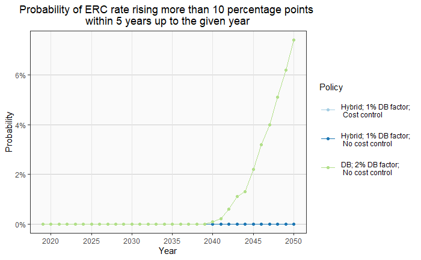

#### Risk of sharp EEC increase

This graph shows the probability that the EEC rate will rise by more than 5 percentage points within any 5-year period leading up to the current year. For example, in 2035 it shows the probability that the EEC rose by 5 percentage points or more in any prior 5-year period (2020-2024, 2021-2025, …, 2031-2035). This is designed to show whether the plan member was likely to face a sharp increase in contribution costs in a short period of time, during the period examined . Note that we use a 5 percentage point change for the EEC and a 10 percentage point change for the ERC, on the belief that individuals may consider a smaller sharp change to their take home pay to be quite significant.

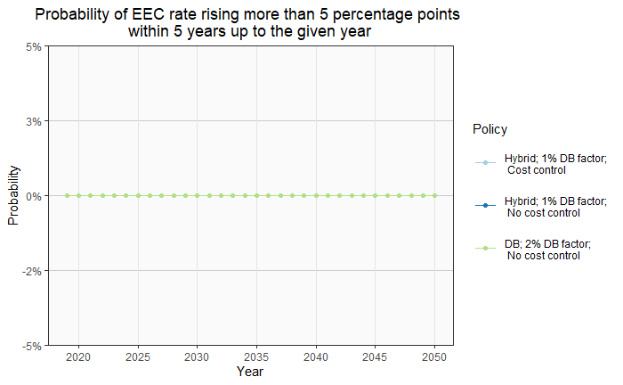

## 3.2 **Analysis of funded status**

### Risk of low funded ratio (cumulative)

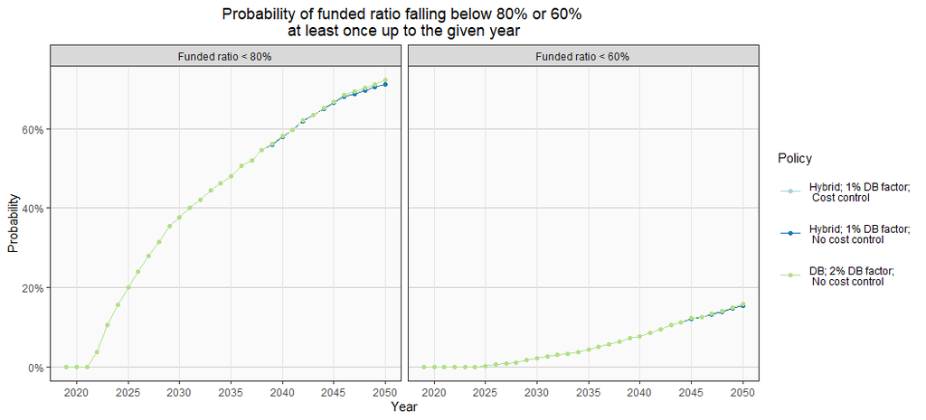

### Risk of low funded ratio (non-cumulative)

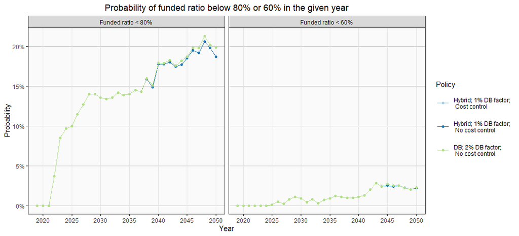

### Probability of full funding

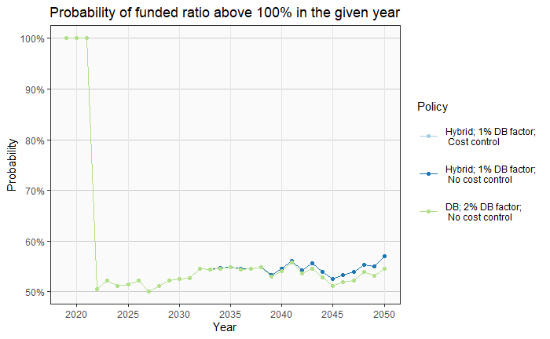

## 3.3 **Analysis of member benefit**

Cohort examined:

- Joined the plan at age 25 in 1985
- Start receiving benefit at age 60 in 2020
- live to age 90 (30 years in retirement)

Currently only DB benefits are included. DC benefits will be added soon.

### distribution of present value of benefit

Distribution of 30-year present value of benefit

| Policy | 90th | 75th | 50th | 25th | 10th | 1th |
| --- | --- | --- | --- | --- | --- | --- |
| Hybrid; 1% DB factor; Cost control | 1,633 | 1,633 | 1,633 | 1,633 | 1,633 | 1,631 |
| Hybrid; 1% DB factor; No cost control | 1,633 | 1,633 | 1,633 | 1,633 | 1,633 | 1,633 |
| DB; 2% DB factor; No cost control | 3,266 | 3,266 | 3,266 | 3,266 | 3,266 | 3,266 |

Note: starting benefit is normalized to $100

### distribution of replacement rate at age 75

Distribution of replacement rate at age 75

For members who retire at age 60 with 35 years of service in 2020

| Policy | 90th | 75th | 50th | 25th | 10th | 1th |
| --- | --- | --- | --- | --- | --- | --- |
| Hybrid; 1% DB factor; Cost control | 65.1% | 65.1% | 65.1% | 65.1% | 65.1% | 65.1% |
| Hybrid; 1% DB factor; No cost control | 65.1% | 65.1% | 65.1% | 65.1% | 65.1% | 65.1% |
| DB; 2% DB factor; No cost control | 130.1% | 130.1% | 130.1% | 130.1% | 130.1% | 130.1% |

Note: benefits at age 75 are adjusted for inflation; assumed inflation = 2.75%